# Papua New Guinea: Mt. Wilhelm - conservation and research area.

[figure not shown]

New Guinea  
Binatang Research Center

# Home

> **WELCOME TO THE MT. WILHELM RAINFORESTS:**
> - EXTRAORDINARILY DIVERSE
> - DEDICATED TO CONSERVATION
> - OPEN TO ECOLOGICAL RESEARCH

Mt. Wilhelm (4509 m asl.) is the highest peak of Papua New Guinea. It is part of the mighty Central Cordillera running over thousand kilometers accross the island of New Guinea.

Uplifted during the collision between Australian and Pacific tectonic plates, it is one of the great tropical mountain ranges, harbouring exceptional biodiversity. Mt. Wilhelm massif harbours a complete elevation range of undisturbed rainforests from lowlands at 200 m asl. to treeline at 3700 m asl.

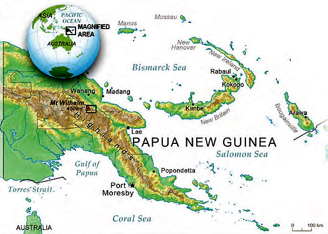

Mt. Wilhelm - Papua New Guinea

[View Larger Map](https://goo.gl/maps/tsh2hriSiwC2)

## Conservation

Rainforests at Mt. Wilhelm, as elsewhere in PNG, are owned by indigenous landowners. The summit area of Mt. Wilhelm above 3200 m asl. has been declared National Park and is one of the top PNG tourist destinations.

However, majority of rainforest diversity is concentrated outside of the National Park and remains unprotected. Several local communities are interested in conserving rainforests on some of their lands, creating thus a transect comprising all types of rainforest ecosystems from lowland to alpine.

## Research

New Guinea [Binatang Research Center](http://baloun.entu.cas.cz/png/parataxoweb.htm) (BRC), a local NGO, is working with rainforest owners to establish a Conservation Area at Mt Wilhelm that could become an internationally important site for ecological research.

BRC and the local communities have established a research transect comprising eight study sites at 500 m elevation increments, spanning from 200 to 3700 m asl. This transect, one of the few in that tropics that encompass complete rainforest elevation range, is now open for research.

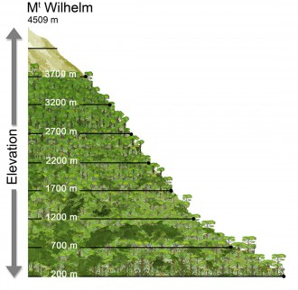

Mt. Wilhelm transect (drawn by M. Leponce)

## Visitors

Mt. Wilhelm communities and BRC welcome all visitors including tourists and researchers. We have logistics in place for your transport and accommodation and trained staff to look after you when you are enjoying your rainforest adventures.

[figure not shown]

Art by Benson A. Bego, a PNG artist

Mt. Wilhelm - conservation and research area.

[figure not shown]